# Task 4

Linas Syvis

**Salyga:**

Aplanke task4 yra duomenu failas, kuriame rasite nekilnojamo turto (o tiksliau gyvenamuju butu) kainas ir kai kurias ju charakteristikas. Jusu uzduotis atlikti issamia tiesine regresija. Lygtis reikalinga prekyboms agentams, kad geriau suprastu kokia įtaka skirtingos charakteristikos daro galutinei kainai.

# Sprendimas

**Nuskaitome duomenis.**

```r
setwd(dir = "C:/Users/Linas/Documents/Ekonometrija 2.2/Praktine ekonometrija")
data <- read.csv2("data.csv", header = TRUE)
```

**Tikrinsime kintamuju multikoliniaruma.** Tinkama priemone patikrinti, ar modelyje egzistuoja multikolinearumo problema, yra Variance Inflation Factor (VIF). Jei kuris nors VIF koeficientas > 10, tai yra neblogas argumentas teigti, kad modelyje yra multikolinearumas.

```r
library(usdm)
vif(data)
```

```
##                   Variables       VIF
## 1                     kaina  4.675778
## 2                    plotas  4.283969
## 3                   aukstas  1.082947
## 4           garsoIzoliacija 11.282639
## 5           silumosLaidumas 11.029037
## 6 atstumasIkiPrekybosCentro  1.008829
```

Dvieju kintamuju (garsoIzoliacija ir silumosLaidumas) VIF > 10, tai sufleruoja apie multikolinearuma.

```r
cor(data$garsoIzoliacija, data$silumosLaidumas)
```

```
## [1] 0.9535669
```

Is tikro, sie du kintamieji koreliuoja labai stipriai (cor = 0.9535669), todel uztenka naudoti tik viena ju. Zmonems renkantis busta, labiau rupi silumos laidumas (siuo atveju remiames logika, o ne skaiciais), todel ismetame kintamaji garsoIzoliacija is duomenu.

```r
ndata <- data[,-4]
vif(ndata)
```

```
##                   Variables      VIF
## 1                     kaina 4.588859
## 2                    plotas 4.236473
## 3                   aukstas 1.074000
## 4           silumosLaidumas 1.210216
## 5 atstumasIkiPrekybosCentro 1.008817
```

Naujuose duomenyse multikolinearumo problemos nebera.

**Ieskosime isskirciu.**

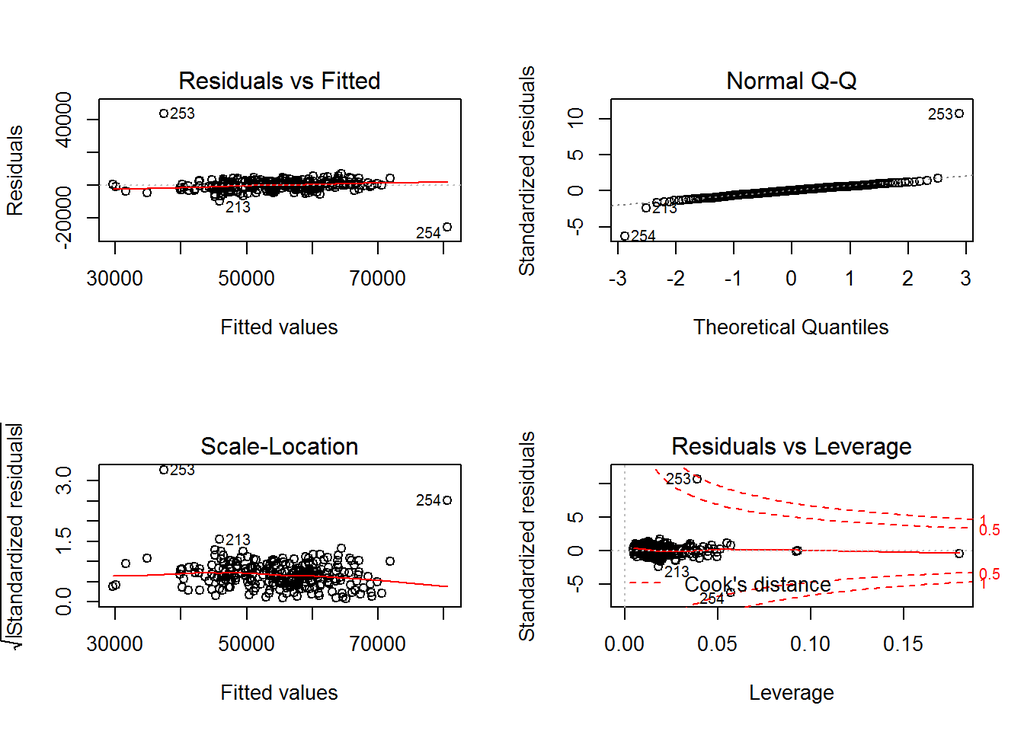

```r
modelis1 <- lm(kaina ~ plotas + aukstas + silumosLaidumas + atstumasIkiPrekybosCentro, data = ndata)
par(mfrow = c(2,2))
plot(modelis1)
```

Sudarome modeli ir isbreziame duomenu diagramas. Plika akimi galime pastebeti galimas isskirtis (253, 254).

```r
library(car)
outlierTest(modelis1)
```

```
##      rstudent unadjusted p-value Bonferonni p
## 253 14.486648         7.1195e-35   1.8084e-32
## 254 -6.882738         4.7778e-11   1.2136e-08
```

outlierTest funkcija suranda duomenu isskirtis. Tai yra 253 ir 254 eilutese esantys duomenys.

```r
databe <- ndata[-c(253, 254),]
modelis1 <- lm(kaina ~ plotas + aukstas + silumosLaidumas + atstumasIkiPrekybosCentro, data = databe)
```

Pasaliname isskirtis.

**Pasaliname nereiksmingus narius**

```r
summary(modelis1)
```

```
##
## Call:
## lm(formula = kaina ~ plotas + aukstas + silumosLaidumas + atstumasIkiPrekybosCentro,
##     data = databe)
##
## Residuals:
##    Min     1Q Median     3Q    Max
##  -9212  -1540     92   1789   5862
##
## Coefficients:
##                           Estimate Std. Error t value Pr(>|t|)
## (Intercept)                7966.67     977.86   8.147 1.86e-14 ***
## plotas                      599.37      12.13  49.410  < 2e-16 ***
## aukstas                     318.66      63.49   5.019 9.95e-07 ***
## silumosLaidumas             527.45      47.52  11.099  < 2e-16 ***
## atstumasIkiPrekybosCentro    85.45      81.38   1.050    0.295
## ---
## Signif. codes:  0 '***' 0.001 '**' 0.01 '*' 0.05 '.' 0.1 ' ' 1
##
## Residual standard error: 2547 on 247 degrees of freedom
## Multiple R-squared:  0.9162, Adjusted R-squared:  0.9149
## F-statistic: 675.5 on 4 and 247 DF,  p-value: < 2.2e-16
```

Ivertiname kintamuju itaka kainai (stulpelis Estimate Std.).

Kintamojo atstumasIkiPrekybosCentro p-value > 0.05, tai leidzia daryti isvada, kad jis nera reiksmingas (priimame H0, kad kintamojo koeficientas lygus 0) ir galime ji pasalinti is modelio.

```r
modelis2 <- lm(kaina ~ plotas + aukstas + silumosLaidumas, data = databe)
summary(modelis2)
```

```
##
## Call:
## lm(formula = kaina ~ plotas + aukstas + silumosLaidumas, data = databe)
##
## Residuals:
##     Min      1Q  Median      3Q     Max
## -9323.0 -1579.4   114.8  1747.6  5759.2
##
## Coefficients:
##                 Estimate Std. Error t value Pr(>|t|)
## (Intercept)      8035.80     975.85   8.235 1.04e-14 ***
## plotas            600.33      12.10  49.622  < 2e-16 ***
## aukstas           318.23      63.50   5.011 1.03e-06 ***
## silumosLaidumas   528.82      47.51  11.130  < 2e-16 ***
## ---
## Signif. codes:  0 '***' 0.001 '**' 0.01 '*' 0.05 '.' 0.1 ' ' 1
##
## Residual standard error: 2548 on 248 degrees of freedom
## Multiple R-squared:  0.9159, Adjusted R-squared:  0.9149
## F-statistic: 899.9 on 3 and 248 DF,  p-value: < 2.2e-16
```

Naujame modelyje nebera nereiksmingu kintamuju.

Patikriname, ar naujas modelis yra tikslesnis. AKAIKE kriterijus “baudzia” uz i modeli itrauktus nereiksmingus narius, todel jis yra vienas geriausiu rodikliu norint palyginti, kuris modelis yra tikslesnis. Kuo mazesnis AKAIKE, tuo tikslesnis modelis.

```r
AIC(modelis1)
```

```
## [1] 4674.872
```

```r
AIC(modelis2)
```

```
## [1] 4673.994
```

Pagal AKAIKE antrasis modelis tikslesnis.

Pastebime, kad “aukstas” yra ranginis kintamasis, todel siuo atveju naudinga pasinaudoti “dummy variables” (naudinga todel, kad taip ivertinsime **kiekvieno** auksto individualia itaka kainai).

```r
aukstasdum = factor(databe$aukstas)
modelis3 <- lm(kaina ~ plotas + aukstasdum + silumosLaidumas, data = databe)
```

Sukuriame nauja modeli, kur kiekvienas aukstas bus kaip atskiras kintamasis (pirmas aukstas bus pagrindas).

```r
summary(modelis3)
```

```
##
## Call:
## lm(formula = kaina ~ plotas + aukstasdum + silumosLaidumas, data = databe)
##
## Residuals:
##    Min     1Q Median     3Q    Max
##  -5708  -1345   -121   1326   5087
##
## Coefficients:
##                 Estimate Std. Error t value Pr(>|t|)
## (Intercept)     4784.007    844.279   5.666 4.15e-08 ***
## plotas           599.096      9.906  60.476  < 2e-16 ***
## aukstasdum2     5515.661    546.941  10.085  < 2e-16 ***
## aukstasdum3     5198.132    542.870   9.575  < 2e-16 ***
## aukstasdum4     6023.111    547.435  11.002  < 2e-16 ***
## aukstasdum5     5126.605    560.228   9.151  < 2e-16 ***
## aukstasdum6     5735.073    577.054   9.939  < 2e-16 ***
## aukstasdum7     5249.698    567.221   9.255  < 2e-16 ***
## aukstasdum8     5656.349    580.023   9.752  < 2e-16 ***
## aukstasdum9     4990.793    572.538   8.717 4.71e-16 ***
## silumosLaidumas  530.897     38.871  13.658  < 2e-16 ***
## ---
## Signif. codes:  0 '***' 0.001 '**' 0.01 '*' 0.05 '.' 0.1 ' ' 1
##
## Residual standard error: 2076 on 241 degrees of freedom
## Multiple R-squared:  0.9457, Adjusted R-squared:  0.9435
## F-statistic:   420 on 10 and 241 DF,  p-value: < 2.2e-16
```

Pastebime, kad pagal itaka kainai labiausiai issiskiria pirmasis aukstas, todel galime visus kitus aukstus apjungti i viena kintamaji.

```r
aukstass=as.numeric(databe$aukstas!=1)
modelis4 <- lm(kaina ~ plotas + aukstass + silumosLaidumas, data = databe)
summary(modelis4)
```

```
##
## Call:
## lm(formula = kaina ~ plotas + aukstass + silumosLaidumas, data = databe)
##
## Residuals:
##     Min      1Q  Median      3Q     Max
## -5710.4 -1360.1    -4.5  1314.9  5087.5
##
## Coefficients:
##                 Estimate Std. Error t value Pr(>|t|)
## (Intercept)     4795.470    837.810   5.724    3e-08 ***
## plotas           598.836      9.827  60.941   <2e-16 ***
## aukstass        5440.159    422.843  12.866   <2e-16 ***
## silumosLaidumas  531.418     38.391  13.842   <2e-16 ***
## ---
## Signif. codes:  0 '***' 0.001 '**' 0.01 '*' 0.05 '.' 0.1 ' ' 1
##
## Residual standard error: 2071 on 248 degrees of freedom
## Multiple R-squared:  0.9444, Adjusted R-squared:  0.9438
## F-statistic:  1405 on 3 and 248 DF,  p-value: < 2.2e-16
```

```r
AIC(modelis2)
```

```
## [1] 4673.994
```

```r
AIC(modelis3)
```

```
## [1] 4577.481
```

```r
AIC(modelis4)
```

```
## [1] 4569.454
```

Pagal AKAIKE ketvirtasis modelis tiksliausias.

**Tikriname heteroskedastiskuma.**

```r
ncvTest(modelis4)
```

```
## Non-constant Variance Score Test
## Variance formula: ~ fitted.values
## Chisquare = 0.06839552    Df = 1     p = 0.7936874
```

ncvTest funkcija atlieka testa su nuline hipoteze, kad modelis homoskedastiskas ir alternatyva, kad modelis heteroskedastiskas.

p-value > 0.05, todel priimame H0, tai reiskia modelis nera heteroskedastiskas.

**Tikriname del autokoreliacijos.**

```r
durbinWatsonTest(modelis4)
```

```
##  lag Autocorrelation D-W Statistic p-value
##    1       0.0429052      1.907047   0.462
##  Alternative hypothesis: rho != 0
```

Funkcija patikrina del liekanu autokoreliacijos.

p-value > 0.05, vadinasi liekanose autokorealiacijos nera.

**Isbrezkime modelio liekanu histograma ir tankio funkcija.**

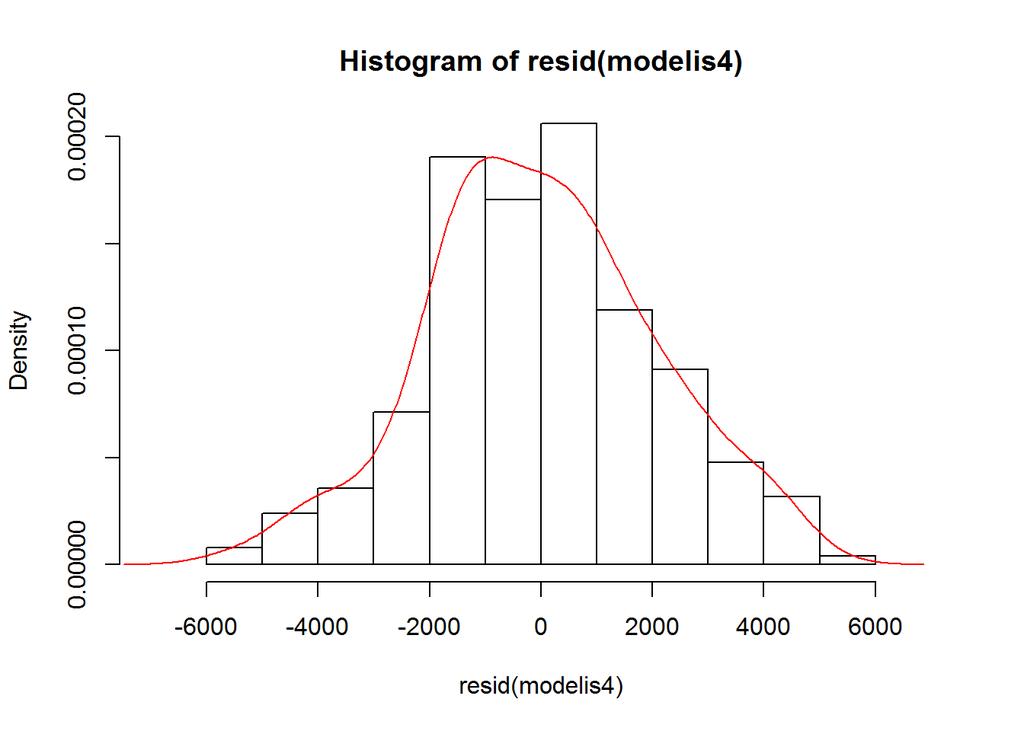

```r
par(mfrow = c(1,1))
hist(resid(modelis4), probability = TRUE, xlim = c(-7000, 7000), ylim = c(0, 0.0002))
lines(density(resid(modelis4)), col = "red")
```

Darome hipoteze, kad modelio liekanos yra pasiskirsciusios pagal normaluji skirstini. Tai tik papildoma sąlyga pasitikrinti, ar mūsų modelis “geras”.

```r
res <- as.vector(modelis4$residuals)
shapiro.test(res)
```

```
##
##  Shapiro-Wilk normality test
##
## data:  res
## W = 0.99376, p-value = 0.3798
```

shapiro.test funkcija patvirtina musu hipoteze, kad modelio liekanos issidesciusios pagal normaluji skirstini (p-value > 0.05).

**Isvada:** Isanalizavus duomenis galime teigti, kad geriausias modelis yra **modelis4**.